# Project: Wrangling and Analyze Data

## Data Gathering

In the cell below, gather **all** three pieces of data for this project and load them in the notebook. **Note:** the methods required to gather each data are different.

1. Directly download the WeRateDogs Twitter archive data (twitter_archive_enhanced.csv)

```python
import pandas as pd #for wrangling and dataframes
import numpy as np # for numerical operations

import requests # for downloading dataset online in real time
import tweepy # for using twitter API in python
import json # for handling json files

import logging
import pprint
import os
import re

import matplotlib.pyplot as plt # for data visualisation
import seaborn as sns # for more formatted and flexible visuals

from datetime import datetime, timezone # for datetime conversion
from dotenv import load_dotenv # environment variable handler
```

> > Import all necessary libraries

```python
# Importing authentication keys

load_dotenv()
my_key = os.getenv('API_KEY')
my_secret = os.getenv('API_KEY_SECRET')
access_token = os.getenv('ACCESS_TOKEN')
access_token_secret = os.getenv('ACCESS_TOKEN_SECRET')
my_token = os.getenv('BEARER_TOKEN')
```

> > extract my API keys from my local files without directly adding them here

```python
# Setting up basic configuration for logging so as to log status and errors during API calls/requests

logging.basicConfig(level=logging.DEBUG, filename="log.log",
                    filemode="w", format="%(asctime)s - %(levelname)s - %(message)s")
```

```python
# OAuth 1.0a Authorization
auth = tweepy.OAuth1UserHandler(
    my_key, my_secret, access_token, access_token_secret)
api = tweepy.API(auth, wait_on_rate_limit=True)


# OAuth 2.0 Authentication
client = tweepy.Client(bearer_token=my_token,
                       consumer_key=my_key,
                       consumer_secret=my_secret,
                       access_token=access_token,
                       access_token_secret=access_token_secret,
                       return_type=dict)
```

```python
# Making a list of all the tweet ids from the given dataset
df_tweets_enhanced = pd.read_csv('twitter-archive-enhanced-2.csv')
id_list = list(df_tweets_enhanced.tweet_id)
```

```python
# Defining a function to get details tweets by id using OAuth 2.0.

def get_tweets(id_list):
    """
    I am getting these tweet fields because I plan using them
    for analysis in the future though for this current analysis,
    I will only be using the public metrics.
    """
    tweet_fields = [
        'id',
        'text',
        'created_at',
        'public_metrics',
        'source',
        'entities',
        'reply_settings',
    ]
    return client.get_tweets(id_list, tweet_fields=tweet_fields)
```

```python
# Function to save tweets in a text file
def save_tweets(json_data):
    with open("tweet_detailed_json.txt", "w") as file:
        file.write(json.dumps(json_data))


# Function to read the tweets from the text file
def read_tweets():
    with open("tweet_detailed_json.txt") as file:
        json_obj = json.load(file)
    return json_obj
```

> > Also the function only executes if the .txt file does not exist in the directory.

```python
def tweet_batches(list_of_ids, batch_size=100):
    if not os.path.exists('tweet_detailed_json.txt'):
        index = 0
        id_queue = []
        tweets_detailed = []
        while len(id_queue) == batch_size or not id_queue:
            id_queue = list_of_ids[index:(index+batch_size)]
            logging.debug(f"Getting tweets {index} to {index+batch_size}")
            tweets_detailed.extend(iter(get_tweets_detailed(id_queue)['data']))
            index += batch_size
        return tweets_detailed
    else:
        logging.warning("""
                    A tweet_detailed_json.txt file already exists in current directory.
                    If you want to make new HTTP requests with this function, delete
                    the 'tweet_detailed_json.txt' file from current directory
                    """)
        return read_tweets_detailed()


# Calling the function to get data for all tweets in the tweet list
tweets = tweet_batches(list_of_ids=id_list)
```

```python
# Confirming the tweets' data was queried properly
print(tweets[0])
```

```
{'id': '892420643555336193', 'entities': {'annotations': [{'start': 8, 'end': 14, 'probability': 0.6637, 'type': 'Person', 'normalized_text': 'Phineas'}], 'urls': [{'start': 86, 'end': 109, 'url': 'https://t.co/MgUWQ76dJU', 'expanded_url': 'https://twitter.com/dog_rates/status/892420643555336193/pho…
```

```python
# Confirming the number of tweets queried
len(tweets)
```

```
2327
```

```python
# Saving the detailed tweet data to a text file
save_tweets(tweets)
```

```python
# Reading the detailed tweet data from the text file
tweets = read_tweets()
```

```python
# Functions to extract only the public metrics from the detailed tweet data and store in a text file

def get_tweets():
    tweet_data = []
    for data in tweets:
        data["public_metrics"]["tweet_id"] = data['id']
        data["public_metrics"]["created_at"] = data['created_at']
        tweet_data.append(data["public_metrics"])
    return tweet_data


def save_tweets():
    with open("tweet_json.txt", "w") as file:
        file.write(json.dumps(get_tweets()))


save_tweets()
```

```python
# Reading the tweets' data to a pandas dataframe

public_metrics = pd.read_json("tweet_json.txt")
public_metrics
```

|  | retweet_count | reply_count | like_count | quote_count | tweet_id | created_at |
| --- | --- | --- | --- | --- | --- | --- |
| 0 | 6975 | 139 | 33711 | 219 | 892420643555336192 | 2017-08-01 16:23:56+00:00 |
| 1 | 5277 | 170 | 29238 | 274 | 892177421306343424 | 2017-08-01 00:17:27+00:00 |
| 2 | 3466 | 110 | 21982 | 145 | 891815181378084864 | 2017-07-31 00:18:03+00:00 |
| 3 | 7197 | 142 | 36813 | 286 | 891689557279858688 | 2017-07-30 15:58:51+00:00 |
| 4 | 7721 | 193 | 35195 | 296 | 891327558926688256 | 2017-07-29 16:00:24+00:00 |
| ... | ... | ... | ... | ... | ... | ... |
| 2322 | 36 | 9 | 88 | 0 | 666049248165822464 | 2015-11-16 00:24:50+00:00 |
| 2323 | 115 | 1 | 246 | 2 | 666044226329800704 | 2015-11-16 00:04:52+00:00 |
| 2324 | 36 | 1 | 100 | 0 | 666033412701032448 | 2015-11-15 23:21:54+00:00 |
| 2325 | 39 | 0 | 112 | 0 | 666029285002620928 | 2015-11-15 23:05:30+00:00 |
| 2326 | 420 | 20 | 2285 | 30 | 666020888022790144 | 2015-11-15 22:32:08+00:00 |

2327 rows × 6 columns

```python
# Saving the new twitter data to a csv
public_metrics.to_csv('tweets_public_metrics.csv', index=False)
```

1. Use the Requests library to download the tweet image prediction (image_predictions.tsv)

```python
def image_pred_data():

    image_pred_url = "https://d17h27t6h515a5.cloudfront.net/topher/2017/August/599fd2ad_image-predictions/image-predictions.tsv"
    image_pred_response = requests.get(image_pred_url)

    with open("image-predictions.tsv", "wb") as file:
        file.write(image_pred_response.content)

    return pd.read_csv("image-predictions.tsv", sep='\t')


df_image_pred = image_pred_data()
```

## Assessing Data

In this section, detect and document at least **eight (8) quality issues and two (2) tidiness issue**. You must use **both** visual assessment programmatic assessement to assess the data.

**Note:** pay attention to the following key points when you access the data.

```python
df_tweets_enhanced.head(3)
```

|  | tweet_id | in_reply_to_status_id | in_reply_to_user_id | timestamp | source | text | retweeted_status_id | retweeted_status_user_id | retweeted_status_timestamp | expanded_urls | rating_numerator | rating_denominator | name | doggo | floofer | pupper | puppo |
| --- | --- | --- | --- | --- | --- | --- | --- | --- | --- | --- | --- | --- | --- | --- | --- | --- | --- |
| 0 | 892420643555336193 | NaN | NaN | 2017-08-01 16:23:56 +0000 | <a href="http://twitter.com/download/iphone" r... | This is Phineas. He's a mystical boy. Only eve... | NaN | NaN | NaN | https://twitter.com/dog_rates/status/892420643... | 13 | 10 | Phineas | None | None | None | None |
| 1 | 892177421306343426 | NaN | NaN | 2017-08-01 00:17:27 +0000 | <a href="http://twitter.com/download/iphone" r... | This is Tilly. She's just checking pup on you.... | NaN | NaN | NaN | https://twitter.com/dog_rates/status/892177421... | 13 | 10 | Tilly | None | None | None | None |
| 2 | 891815181378084864 | NaN | NaN | 2017-07-31 00:18:03 +0000 | <a href="http://twitter.com/download/iphone" r... | This is Archie. He is a rare Norwegian Pouncin... | NaN | NaN | NaN | https://twitter.com/dog_rates/status/891815181... | 12 | 10 | Archie | None | None | None | None |

```python
df_tweets_enhanced.info()
```

```
<class 'pandas.core.frame.DataFrame'>
RangeIndex: 2356 entries, 0 to 2355
Data columns (total 17 columns):
 #   Column                      Non-Null Count  Dtype
---  ------                      --------------  -----
 0   tweet_id                    2356 non-null   int64
 1   in_reply_to_status_id       78 non-null     float64
 2   in_reply_to_user_id         78 non-null     float64
 3   timestamp                   2356 non-null   object
 4   source                      2356 non-null   object
 5   text                        2356 non-null   object
 6   retweeted_status_id         181 non-null    float64
 7   retweeted_status_user_id    181 non-null    float64
 8   retweeted_status_timestamp  181 non-null    object
 9   expanded_urls               2297 non-null   object
 10  rating_numerator            2356 non-null   int64
 11  rating_denominator          2356 non-null   int64
 12  name                        2356 non-null   object
 13  doggo                       2356 non-null   object
 14  floofer                     2356 non-null   object
 15  pupper                      2356 non-null   object
 16  puppo                       2356 non-null   object
dtypes: float64(4), int64(3), object(10)
memory usage: 313.0+ KB
```

- **[Timestamp]** is an object data type instead of datetime
- **181** retweet values indicated by the non-null values in **[retweeted_status_id, retweeted_status_user_id, retweeted_status_timestamp]** columns
- the IDs **[tweet_id,in_reply_to_status_id, in_reply_to_user_id, retweeted_status_id, retweeted_status_user_id ]** are all numerical types instead of object: it has to be object type because I will not use them for numerical computation

```python
df_tweets_enhanced.isnull().sum()/df_tweets_enhanced.shape[0]
```

```
tweet_id                      0.000000
in_reply_to_status_id         0.966893
in_reply_to_user_id           0.966893
timestamp                     0.000000
source                        0.000000
text                          0.000000
retweeted_status_id           0.923175
retweeted_status_user_id      0.923175
retweeted_status_timestamp    0.923175
expanded_urls                 0.025042
rating_numerator              0.000000
rating_denominator            0.000000
name                          0.000000
doggo                         0.000000
floofer                       0.000000
pupper                        0.000000
puppo                         0.000000
dtype: float64
```

- **[in_reply_to_status_id, in_reply_to_user_id]** columns has 96.6% missing values
- **[retweeted_status_id, retweeted_status_user_id, retweeted_status_timestamp]** columns has 92.2% missing values

```python
df_tweets_enhanced.duplicated().sum()
```

```
0
```

- no dulpicate values

```python
# function to get unique values
def unique_value_count(column):
    unique_counts = column.value_counts()
    print(unique_counts)
```

```python
unique_value_count(df_tweets_enhanced.doggo)
```

```
None     2259
doggo      97
Name: doggo, dtype: int64
```

- 97 of all rated dogs are of doggo type

```python
unique_value_count(df_tweets_enhanced.floofer)
```

```
None       2346
floofer      10
Name: floofer, dtype: int64
```

- only 10 are floofer breed of all rated dogs

```python
unique_value_count(df_tweets_enhanced.pupper)
```

```
None      2099
pupper     257
Name: pupper, dtype: int64
```

- 257 are pupper dog breeds

```python
unique_value_count(df_tweets_enhanced.puppo)
```

```
None     2326
puppo      30
Name: puppo, dtype: int64
```

- 30 dogs are of puppo breed

```python
unique_value_count(df_tweets_enhanced.name)
```

```
None          745
a              55
Charlie        12
Cooper         11
Lucy           11
             ...
Dex             1
Ace             1
Tayzie          1
Grizzie         1
Christoper      1
Name: name, Length: 957, dtype: int64
```

- None is used in place of NaN for missing values. lets check further
- some of the names are not valids names for dogs

```python
df_tweets_enhanced[['name', 'doggo', 'floofer', 'pupper', 'puppo']].info()
```

```
<class 'pandas.core.frame.DataFrame'>
RangeIndex: 2356 entries, 0 to 2355
Data columns (total 5 columns):
 #   Column   Non-Null Count  Dtype
---  ------   --------------  -----
 0   name     2356 non-null   object
 1   doggo    2356 non-null   object
 2   floofer  2356 non-null   object
 3   pupper   2356 non-null   object
 4   puppo    2356 non-null   object
dtypes: object(5)
memory usage: 92.2+ KB
```

- Yes, many Null values that was not captured as missing values in **[name, doggo, floofer, pupper, puppo]** columns, instead recorded as NONE

```python
# Increasing the maximum column width so we can better see the contents of the text column
pd.set_option('max_colwidth', 1000)
```

```python
df_tweets_enhanced[df_tweets_enhanced.rating_denominator != 10][[
    'tweet_id', 'text', 'rating_numerator', 'rating_denominator']]
```

|  | tweet_id | text | rating_numerator | rating_denominator |
| --- | --- | --- | --- | --- |
| 313 | 835246439529840640 | @jonnysun @Lin_Manuel ok jomny I know you're excited but 960/00 isn't a valid rating, 13/10 is tho | 960 | 0 |
| 342 | 832088576586297345 | @docmisterio account started on 11/15/15 | 11 | 15 |
| 433 | 820690176645140481 | The floofs have been released I repeat the floofs have been released. 84/70 https://t.co/NIYC820tmd | 84 | 70 |
| 516 | 810984652412424192 | Meet Sam. She smiles 24/7 &amp; secretly aspires to be a reindeer. \nKeep Sam smiling by clicking and sharing this link:\nhttps://t.co/98tB8y7y7t https://t.co/LouL5vdvxx | 24 | 7 |
| 784 | 775096608509886464 | RT @dog_rates: After so many requests, this is Bretagne. She was the last surviving 9/11 search dog, and our second ever 14/10. RIP https:/… | 9 | 11 |
| 902 | 758467244762497024 | Why does this never happen at my front door... 165/150 https://t.co/HmwrdfEfUE | 165 | 150 |
| 1068 | 740373189193256964 | After so many requests, this is Bretagne. She was the last surviving 9/11 search dog, and our second ever 14/10. RIP https://t.co/XAVDNDaVgQ | 9 | 11 |
| 1120 | 731156023742988288 | Say hello to this unbelievably well behaved squad of doggos. 204/170 would try to pet all at once https://t.co/yGQI3He3xv | 204 | 170 |
| 1165 | 722974582966214656 | Happy 4/20 from the squad! 13/10 for all https://t.co/eV1diwds8a | 4 | 20 |
| 1202 | 716439118184652801 | This is Bluebert. He just saw that both #FinalFur match ups are split 50/50. Amazed af. 11/10 https://t.co/Kky1DPG4iq | 50 | 50 |
| 1228 | 713900603437621249 | Happy Saturday here's 9 puppers on a bench. 99/90 good work everybody https://t.co/mpvaVxKmc1 | 99 | 90 |
| 1254 | 710658690886586372 | Here's a brigade of puppers. All look very prepared for whatever happens next. 80/80 https://t.co/0eb7R1Om12 | 80 | 80 |
| 1274 | 709198395643068416 | From left to right:\nCletus, Jerome, Alejandro, Burp, &amp; Titson\nNone know where camera is. 45/50 would hug all at once https://t.co/sedre1ivTK | 45 | 50 |
| 1351 | 704054845121142784 | Here is a whole flock of puppers. 60/50 I'll take the lot https://t.co/9dpcw6MdWa | 60 | 50 |
| 1433 | 697463031882764288 | Happy Wednesday here's a bucket of pups. 44/40 would pet all at once https://t.co/HppvrYuamZ | 44 | 40 |
| 1598 | 686035780142297088 | Yes I do realize a rating of 4/20 would've been fitting. However, it would be unjust to give these cooperative pups that low of a rating | 4 | 20 |
| 1634 | 684225744407494656 | Two sneaky puppers were not initially seen, moving the rating to 143/130. Please forgive us. Thank you https://t.co/kRK51Y5ac3 | 143 | 130 |
| 1635 | 684222868335505415 | Someone help the girl is being mugged. Several are distracting her while two steal her shoes. Clever puppers 121/110 https://t.co/1zfnTJLt55 | 121 | 110 |
| 1662 | 682962037429899265 | This is Darrel. He just robbed a 7/11 and is in a high speed police chase. Was just spotted by the helicopter 10/10 https://t.co/7EsP8LmSp5 | 7 | 11 |
| 1663 | 682808988178739200 | I'm aware that I could've said 20/16, but here at WeRateDogs we are very professional. An inconsistent rating scale is simply irresponsible | 20 | 16 |
| 1779 | 677716515794329600 | IT'S PUPPERGEDDON. Total of 144/120 ...I think https://t.co/ZanVtAtvIq | 144 | 120 |
| 1843 | 675853064436391936 | Here we have an entire platoon of puppers. Total score: 88/80 would pet all at once https://t.co/y93p6FLvVw | 88 | 80 |
| 2335 | 666287406224695296 | This is an Albanian 3 1/2 legged Episcopalian. Loves well-polished hardwood flooring. Penis on the collar. 9/10 https://t.co/d9NcXFKwLv | 1 | 2 |

- some of the ratings(i.e #313) is not a valid rating should be replaced with 13 and 10.
- some observations has double ratings with the last rating usually accepted as the real rating.
- some of the text column has a url
- text column has the rating values inside of it.
- @xxxxx mentioning twitter handles in the text column

```python
df_tweets_enhanced[df_tweets_enhanced['text'].apply(lambda x: len(re.findall(
    "-?\d+\.\d+\/10|-?\d+\/10", x)) > 1)][['tweet_id', 'text', 'rating_numerator', 'rating_denominator']]
```

|  | tweet_id | text | rating_numerator | rating_denominator |
| --- | --- | --- | --- | --- |
| 55 | 881633300179243008 | @roushfenway These are good dogs but 17/10 is an emotional impulse rating. More like 13/10s | 17 | 10 |
| 561 | 802624713319034886 | RT @dog_rates: "Yep... just as I suspected. You're not flossing." 12/10 and 11/10 for the pup not flossing https://t.co/SuXcI9B7pQ | 12 | 10 |
| 766 | 777684233540206592 | "Yep... just as I suspected. You're not flossing." 12/10 and 11/10 for the pup not flossing https://t.co/SuXcI9B7pQ | 12 | 10 |
| 860 | 763167063695355904 | RT @dog_rates: Meet Eve. She's a raging alcoholic 8/10 (would b 11/10 but pupper alcoholism is a tragic issue that I can't condone) https:/… | 8 | 10 |
| 1007 | 747600769478692864 | This is Bookstore and Seaweed. Bookstore is tired and Seaweed is an asshole. 10/10 and 7/10 respectively https://t.co/eUGjGjjFVJ | 10 | 10 |
| 1222 | 714258258790387713 | Meet Travis and Flurp. Travis is pretty chill but Flurp can't lie down properly. 10/10 &amp; 8/10\nget it together Flurp https://t.co/Akzl5ynMmE | 10 | 10 |
| 1359 | 703356393781329922 | This is Socks. That water pup w the super legs just splashed him. Socks did not appreciate that. 9/10 and 2/10 https://t.co/8rc5I22bBf | 9 | 10 |
| 1459 | 695064344191721472 | This may be the greatest video I've ever been sent. 4/10 for Charles the puppy, 13/10 overall. (Vid by @stevenxx_) https://t.co/uaJmNgXR2P | 4 | 10 |
| 1465 | 694352839993344000 | Meet Oliviér. He takes killer selfies. Has a dog of his own. It leaps at random &amp; can't bark for shit. 10/10 &amp; 5/10 https://t.co/6NgsQJuSBJ | 10 | 10 |
| 1508 | 691483041324204033 | When bae says they can't go out but you see them with someone else that same night. 5/10 &amp; 10/10 for heartbroken pup https://t.co/aenk0KpoWM | 5 | 10 |
| 1525 | 690400367696297985 | This is Eriq. His friend just reminded him of last year's super bowl. Not cool friend\n10/10 for Eriq\n6/10 for friend https://t.co/PlEXTofdpf | 10 | 10 |
| 1538 | 689835978131935233 | Meet Fynn &amp; Taco. Fynn is an all-powerful leaf lord and Taco is in the wrong place at the wrong time. 11/10 &amp; 10/10 https://t.co/MuqHPvtL8c | 11 | 10 |
| 1795 | 677314812125323265 | Meet Tassy &amp; Bee. Tassy is pretty chill, but Bee is convinced the Ruffles are haunted. 10/10 &amp; 11/10 respectively https://t.co/fgORpmTN9C | 10 | 10 |
| 1832 | 676191832485810177 | These two pups just met and have instantly bonded. Spectacular scene. Mesmerizing af. 10/10 and 7/10 for blue dog https://t.co/gwryaJO4tC | 10 | 10 |
| 1897 | 674737130913071104 | Meet Rufio. He is unaware of the pink legless pupper wrapped around him. Might want to get that checked 10/10 &amp; 4/10 https://t.co/KNfLnYPmYh | 10 | 10 |
| 1901 | 674646392044941312 | Two gorgeous dogs here. Little waddling dog is a rebel. Refuses to look at camera. Must be a preteen. 5/10 &amp; 8/10 https://t.co/YPfw7oahbD | 5 | 10 |
| 1970 | 673295268553605120 | Meet Eve. She's a raging alcoholic 8/10 (would b 11/10 but pupper alcoholism is a tragic issue that I can't condone) https://t.co/U36HYQIijg | 8 | 10 |
| 2010 | 672248013293752320 | 10/10 for dog. 7/10 for cat. 12/10 for human. Much skill. Would pet all https://t.co/uhx5gfpx5k | 10 | 10 |
| 2064 | 671154572044468225 | Meet Holly. She's trying to teach small human-like pup about blocks but he's not paying attention smh. 11/10 &amp; 8/10 https://t.co/RcksaUrGNu | 11 | 10 |
| 2113 | 670434127938719744 | Meet Hank and Sully. Hank is very proud of the pumpkin they found and Sully doesn't give a shit. 11/10 and 8/10 https://t.co/cwoP1ftbrj | 11 | 10 |
| 2177 | 669037058363662336 | Here we have Pancho and Peaches. Pancho is a Condoleezza Gryffindor, and Peaches is just an asshole. 10/10 &amp; 7/10 https://t.co/Lh1BsJrWPp | 10 | 10 |
| 2216 | 668537837512433665 | This is Spark. He's nervous. Other dog hasn't moved in a while. Won't come when called. Doesn't fetch well 8/10&amp;1/10 https://t.co/stEodX9Aba | 8 | 10 |
| 2263 | 667544320556335104 | This is Kial. Kial is either wearing a cape, which would be rad, or flashing us, which would be rude. 10/10 or 4/10 https://t.co/8zcwIoiuqR | 10 | 10 |
| 2272 | 667491009379606528 | Two dogs in this one. Both are rare Jujitsu Pythagoreans. One slightly whiter than other. Long legs. 7/10 and 8/10 https://t.co/ITxxcc4v9y | 7 | 10 |
| 2298 | 667070482143944705 | After much debate this dog is being upgraded to 10/10. I repeat 10/10 | 10 | 10 |
| 2306 | 666835007768551424 | These are Peruvian Feldspars. Their names are Cupit and Prencer. Both resemble Rand Paul. Sick outfits 10/10 &amp; 10/10 https://t.co/ZnEMHBsAs1 | 10 | 10 |

- all the above has double ratings.

```python
df_image_pred.head(1)
```

|  | tweet_id | jpg_url | img_num | p1 | p1_conf | p1_dog | p2 | p2_conf | p2_dog | p3 | p3_conf | p3_dog |
| --- | --- | --- | --- | --- | --- | --- | --- | --- | --- | --- | --- | --- |
| 0 | 666020888022790149 | https://pbs.twimg.com/media/CT4udn0WwAA0aMy.jpg | 1 | Welsh_springer_spaniel | 0.465074 | True | collie | 0.156665 | True | Shetland_sheepdog | 0.061428 | True |

- column headers are non-descriptive

```python
df_image_pred[['p1', 'p2', 'p3']].head(10)
```

|  | p1 | p2 | p3 |
| --- | --- | --- | --- |
| 0 | Welsh_springer_spaniel | collie | Shetland_sheepdog |
| 1 | redbone | miniature_pinscher | Rhodesian_ridgeback |
| 2 | German_shepherd | malinois | bloodhound |
| 3 | Rhodesian_ridgeback | redbone | miniature_pinscher |
| 4 | miniature_pinscher | Rottweiler | Doberman |
| 5 | Bernese_mountain_dog | English_springer | Greater_Swiss_Mountain_dog |
| 6 | box_turtle | mud_turtle | terrapin |
| 7 | chow | Tibetan_mastiff | fur_coat |
| 8 | shopping_cart | shopping_basket | golden_retriever |
| 9 | miniature_poodle | komondor | soft-coated_wheaten_terrier |

- predicted names are seperated by underscores instead of whitespace and they are not capitalized.

### Quality issues

#### df_enhanced_archive dataset

1. retweets data observations in the tweets datasets.
2. ['retweeted_status_id', 'retweeted_status_user_id','retweeted_status_timestamp', 'in_reply_to_status_id', 'in_reply_to_user_id'] are not necesaary for analysis
3. the IDs **[tweet_id,in_reply_to_status_id, in_reply_to_user_id, retweeted_status_id, retweeted_status_user_id ]** are all numerical types instead of object: it has to be object type because I will not use them for numerical computation
4. **[Timestamp]** is an object type instead of datetime
5. **[name, doggo, floofer, pupper, puppo]** columns with NONE instead of null(missing values)
6. invalid ratings at the [rating_denominator and rating_numerator]
7. some of the dogs names are invalid names for dogs

#### Df_image_Pred Dataset

1. predicted names are seperated by underscores instead of whitespace and they are not capitalized

### Tidiness issues

1. 'doggo', 'floofer', 'pupper', 'puppo', are dog stages that should be in single column instead of 4 columns
2. the datasets being in separate dataframes.

## Cleaning Data

In this section, clean **all** of the issues you documented while assessing.

**Note:** Make a copy of the original data before cleaning. Cleaning includes merging individual pieces of data according to the rules of [tidy data](https://cran.r-project.org/web/packages/tidyr/vignettes/tidy-data.html). The result should be a high-quality and tidy master pandas DataFrame (or DataFrames, if appropriate).

```python
# Make copies of original pieces of data
# Make copies of original pieces of data

image_pred_copy = df_image_pred.copy()
public_metrics_copy = public_metrics.copy()
tweets_enhanced_copy = df_tweets_enhanced.copy()
```

# **quality Issues**:

### Issue #1:

#### Define:

> remove all retweeted data points from the tweet_enhanced_copy by filtering for the null values along retweet_id column

#### Code

```python
tweets_enhanced_copy.shape
```

```
(2356, 17)
```

```python
# Removing the rows
tweets_enhanced_copy = tweets_enhanced_copy[tweets_enhanced_copy["retweeted_status_id"].isna(
)]
```

#### Test

```python
tweets_enhanced_copy.shape
```

```
(2175, 17)
```

> 181 rows with non-null values has been removed

### Issue #2:

#### Define

> remove retweets and reply columns

#### Code

```python
# Droping the columns
tweets_enhanced_copy.drop(['retweeted_status_id',
                                      'retweeted_status_user_id',
                                      'retweeted_status_timestamp',
                                      'in_reply_to_status_id',
                                      'in_reply_to_user_id'], axis = 1,
                             inplace=True)
```

#### Test

```python
tweets_enhanced_copy.head(1)
```

|  | tweet_id | timestamp | source | text | expanded_urls | rating_numerator | rating_denominator | name | doggo | floofer | pupper | puppo |
| --- | --- | --- | --- | --- | --- | --- | --- | --- | --- | --- | --- | --- |
| 0 | 892420643555336193 | 2017-08-01 16:23:56 +0000 | <a href="http://twitter.com/download/iphone" r... | This is Phineas. He's a mystical boy. Only eve... | https://twitter.com/dog_rates/status/892420643... | 13 | 10 | Phineas | None | None | None | None |

```python
tweets_enhanced_copy.shape
```

```
(2175, 12)
```

> columns ['retweeted_status_id','retweeted_status_user_id', 'retweeted_status_timestamp', 'in_reply_to_status_id','in_reply_to_user_id' ] removed

### Issue #3:

### define

Change the data types of tweet_id in all datasets

### code

```python
# Changing the datatypes
public_metrics_copy = public_metrics_copy.astype({'tweet_id': 'str'})
```

```python
tweets_enhanced_copy = tweets_enhanced_copy.astype({'tweet_id': 'str'})
```

```python
image_pred_copy = image_pred_copy.astype({'tweet_id': 'str'})
```

### test

```python
public_metrics_copy.dtypes, tweets_enhanced_copy.dtypes, image_pred_copy.dtypes
```

```
(retweet_count                  int64
 reply_count                    int64
 like_count                     int64
 quote_count                    int64
 tweet_id                      object
 created_at       datetime64[ns, UTC]
 dtype: object,
 tweet_id              object
 timestamp             object
 source                object
 text                  object
 expanded_urls         object
 rating_numerator       int64
 rating_denominator     int64
 name                  object
 doggo                 object
 floofer               object
 pupper                object
 puppo                 object
 dtype: object,
 tweet_id     object
 jpg_url      object
 img_num       int64
 p1           object
 p1_conf     float64
 p1_dog         bool
 p2           object
 p2_conf     float64
 p2_dog         bool
 p3           object
 p3_conf     float64
 p3_dog         bool
 dtype: object)
```

### Issue #4:

### define

change Timestamp to datetime

### code

```python
tweets_enhanced_copy.columns
```

```
Index(['tweet_id', 'timestamp', 'source', 'text', 'expanded_urls',
       'rating_numerator', 'rating_denominator', 'name', 'doggo', 'floofer',
       'pupper', 'puppo'],
      dtype='object')
```

```python
# Changing the timestamp column datatype to datetime
tweets_enhanced_copy['timestamp'] = pd.to_datetime(
    tweets_enhanced_copy['timestamp'])
```

### test

```python
tweets_enhanced_copy.timestamp.dtypes
```

```
datetime64[ns, UTC]
```

### code

```python
comlums = tweets_enhanced_copy.columns
```

```python
tweets_enhanced_copy[comlums].replace('None', None, inplace=True)
```

### test

```python
tweets_enhanced_copy[['name', 'doggo', 'floofer', 'pupper', 'puppo']].info()
```

```
<class 'pandas.core.frame.DataFrame'>
Int64Index: 2175 entries, 0 to 2355
Data columns (total 5 columns):
 #   Column   Non-Null Count  Dtype
---  ------   --------------  -----
 0   name     2175 non-null   object
 1   doggo    2175 non-null   object
 2   floofer  2175 non-null   object
 3   pupper   2175 non-null   object
 4   puppo    2175 non-null   object
dtypes: object(5)
memory usage: 102.0+ KB
```

### Issue #6:

### define

> Remove invalid ratings creating a function to extract ratings, both decimal and non decimal. It only extracts ratings with denominator of 10 and it also extracts negative ratings. Some of the tweets in the dataset have more than one dog rating so extract only last

### Code

```python
def extract_rating(text):
    try:
        return re.findall("-?\d+\.\d+\/10|-?\d+\/10", text)[-1]
    except IndexError:
        return np.nan
```

```python
# Function to split the rating numbers to fill the numerator and denominator columns in the dataset
def split_rating(rating, index):
    try:
        return rating.split("/")[index]
    except AttributeError:
        return 0
```

```python
# Extracting the ratings with the new regular expression and storing in a new column
tweets_enhanced_copy['rating'] = tweets_enhanced_copy['text'].apply(
    lambda x: extract_rating(x))

# Confirming changes
tweets_enhanced_copy[['text', 'rating_numerator',
                         'rating_denominator', 'rating']]
```

|  | text | rating_numerator | rating_denominator | rating |
| --- | --- | --- | --- | --- |
| 0 | This is Phineas. He's a mystical boy. Only eve... | 13 | 10 | 13/10 |
| 1 | This is Tilly. She's just checking pup on you.... | 13 | 10 | 13/10 |
| 2 | This is Archie. He is a rare Norwegian Pouncin... | 12 | 10 | 12/10 |
| 3 | This is Darla. She commenced a snooze mid meal... | 13 | 10 | 13/10 |
| 4 | This is Franklin. He would like you to stop ca... | 12 | 10 | 12/10 |
| ... | ... | ... | ... | ... |
| 2351 | Here we have a 1949 1st generation vulpix. Enj... | 5 | 10 | 5/10 |
| 2352 | This is a purebred Piers Morgan. Loves to Netf... | 6 | 10 | 6/10 |
| 2353 | Here is a very happy pup. Big fan of well-main... | 9 | 10 | 9/10 |
| 2354 | This is a western brown Mitsubishi terrier. Up... | 7 | 10 | 7/10 |
| 2355 | Here we have a Japanese Irish Setter. Lost eye... | 8 | 10 | 8/10 |

2175 rows × 4 columns

```python
# Extracting the numerators and denominators again
tweets_enhanced_copy['rating_numerator'] = tweets_enhanced_copy['rating'].apply(
    lambda x: split_rating(x, 0))
tweets_enhanced_copy['rating_denominator'] = tweets_enhanced_copy['rating'].apply(
    lambda x: split_rating(x, 1))

# Confirming changes
tweets_enhanced_copy[['text', 'rating_numerator',
                         'rating_denominator', 'rating']]
```

|  | text | rating_numerator | rating_denominator | rating |
| --- | --- | --- | --- | --- |
| 0 | This is Phineas. He's a mystical boy. Only eve... | 13 | 10 | 13/10 |
| 1 | This is Tilly. She's just checking pup on you.... | 13 | 10 | 13/10 |
| 2 | This is Archie. He is a rare Norwegian Pouncin... | 12 | 10 | 12/10 |
| 3 | This is Darla. She commenced a snooze mid meal... | 13 | 10 | 13/10 |
| 4 | This is Franklin. He would like you to stop ca... | 12 | 10 | 12/10 |
| ... | ... | ... | ... | ... |
| 2351 | Here we have a 1949 1st generation vulpix. Enj... | 5 | 10 | 5/10 |
| 2352 | This is a purebred Piers Morgan. Loves to Netf... | 6 | 10 | 6/10 |
| 2353 | Here is a very happy pup. Big fan of well-main... | 9 | 10 | 9/10 |
| 2354 | This is a western brown Mitsubishi terrier. Up... | 7 | 10 | 7/10 |
| 2355 | Here we have a Japanese Irish Setter. Lost eye... | 8 | 10 | 8/10 |

2175 rows × 4 columns

```python
# Changing the datatype to float and int respectively
tweets_enhanced_copy = tweets_enhanced_copy.astype(
    {'rating_numerator': 'float64'})
```

```python
tweets_enhanced_copy['rating_denominator'] = tweets_enhanced_copy['rating_denominator'].astype(
    int)
```

### Test

```python
tweets_enhanced_copy.sample(5)
```

|  | tweet_id | timestamp | source | text | expanded_urls | rating_numerator | rating_denominator | name | doggo | floofer | pupper | puppo | rating |
| --- | --- | --- | --- | --- | --- | --- | --- | --- | --- | --- | --- | --- | --- |
| 362 | 829449946868879360 | 2017-02-08 22:00:52+00:00 | <a href="http://twitter.com/download/iphone" r... | Here's a stressed doggo. Had a long day. Many ... | https://twitter.com/dog_rates/status/829449946... | 11.0 | 10 | None | doggo | None | None | None | 11/10 |
| 2130 | 670093938074779648 | 2015-11-27 04:16:59+00:00 | <a href="http://twitter.com/download/iphone" r... | This is Wally. He's a Flaccid Mitochondria. Go... | https://twitter.com/dog_rates/status/670093938... | 9.0 | 10 | Wally | None | None | None | None | 9/10 |
| 711 | 784517518371221505 | 2016-10-07 22:15:26+00:00 | <a href="http://twitter.com/download/iphone" r... | This is Frankie. He has yet to learn how to co... | https://twitter.com/dog_rates/status/784517518... | 11.0 | 10 | Frankie | None | None | None | None | 11/10 |
| 2195 | 668872652652679168 | 2015-11-23 19:24:02+00:00 | <a href="http://twitter.com/download/iphone" r... | This is Amélie. She is a confident white colle... | https://twitter.com/dog_rates/status/668872652... | 11.0 | 10 | Amélie | None | None | None | None | 11/10 |
| 1794 | 677328882937298944 | 2015-12-17 03:26:04+00:00 | <a href="http://twitter.com/download/iphone" r... | This is Derek. All the dogs adore Derek. He's ... | https://twitter.com/dog_rates/status/677328882... | 10.0 | 10 | Derek | None | None | None | None | 10/10 |

```python
tweets_enhanced_copy.info()
```

```
<class 'pandas.core.frame.DataFrame'>
Int64Index: 2175 entries, 0 to 2355
Data columns (total 13 columns):
 #   Column              Non-Null Count  Dtype
---  ------              --------------  -----
 0   tweet_id            2175 non-null   object
 1   timestamp           2175 non-null   datetime64[ns, UTC]
 2   source              2175 non-null   object
 3   text                2175 non-null   object
 4   expanded_urls       2117 non-null   object
 5   rating_numerator    2175 non-null   float64
 6   rating_denominator  2175 non-null   int32
 7   name                2175 non-null   object
 8   doggo               2175 non-null   object
 9   floofer             2175 non-null   object
 10  pupper              2175 non-null   object
 11  puppo               2175 non-null   object
 12  rating              2159 non-null   object
dtypes: datetime64[ns, UTC](1), float64(1), int32(1), object(10)
memory usage: 229.4+ KB
```

```python
image_pred_copy.head(1)
```

[output not shown]

### Issue #7:

### define:

define a function that removes invalid names from the name column. first by targeting names in lowercase.

### code

```python
# Function to remove names that are lower case
def remove_invalid(name):
    try:
        return None if name[0].islower() else value
    except Exception:
        return name


def check_invalid(name):
    try:
        return bool(name[0].islower())
    except Exception:
        return False

# Replacing invalid dog names with None with remove_invalid function
tweets_enhanced_copy['name'] = tweets_enhanced_copy['name'].apply(lambda x: remove_invalid(x))
```

### Test

```python
tweets_enhanced_copy[['name']].sample()
```

|  | name |
| --- | --- |
| 1210 | Zeus |

```python
# Confirming there are no invalid names again in the dataset
tweets_enhanced_copy[tweets_enhanced_copy['name'].apply(lambda x: check_invalid(x))]
```

|  | tweet_id | timestamp | source | text | expanded_urls | rating_numerator | rating_denominator | name | doggo | floofer | pupper | puppo | rating |
| --- | --- | --- | --- | --- | --- | --- | --- | --- | --- | --- | --- | --- | --- |

### Issue #8:

### define:

Remove the underscore in the dog breed names and replace it with whitespace.

### code

```python
def reformat_dog_names():
    columns = ['p1', 'p2', 'p3']  # List of columns to target
    for column in columns:
        image_pred_copy[column] = image_pred_copy[column].apply(
            lambda x: " ".join(x.split('_')).title())
        image_pred_copy[column] = image_pred_copy[column].apply(
            lambda x: " ".join(x.split('_')).title())


reformat_dog_names()
```

### test

```python
image_pred_copy[['p1', 'p2', 'p3']]
```

|  | p1 | p2 | p3 |
| --- | --- | --- | --- |
| 0 | Welsh Springer Spaniel | Collie | Shetland Sheepdog |
| 1 | Redbone | Miniature Pinscher | Rhodesian Ridgeback |
| 2 | German Shepherd | Malinois | Bloodhound |
| 3 | Rhodesian Ridgeback | Redbone | Miniature Pinscher |
| 4 | Miniature Pinscher | Rottweiler | Doberman |
| ... | ... | ... | ... |
| 2070 | Basset | English Springer | German Short-Haired Pointer |
| 2071 | Paper Towel | Labrador Retriever | Spatula |
| 2072 | Chihuahua | Malamute | Kelpie |
| 2073 | Chihuahua | Pekinese | Papillon |
| 2074 | Orange | Bagel | Banana |

2075 rows × 3 columns

# **Tidyness Issues**:

### Issue #1:

### define:

Create a single column to accomodate dog stages columns in one instead of four columns

### code

```python
#Create a list for the columns
dog_stages = ['doggo', 'puppo', 'pupper', 'floofer']

#Create a loop to replace the None in the 4 columns with space ''
for i in dog_stages:
    tweets_enhanced_copy[i] = tweets_enhanced_copy[i].replace('None','')

#Create a new column for dog stage and fill it with the data in the 4 columns
tweets_enhanced_copy['dog_stage'] = tweets_enhanced_copy['doggo'] + tweets_enhanced_copy['puppo'] + tweets_enhanced_copy['pupper'] + tweets_enhanced_copy['floofer']
```

```python
# Dropping doggo, puppo, pupper, floofer columns
tweets_enhanced_copy.drop(
    columns=['doggo', 'floofer', 'pupper', 'puppo'], inplace=True)
```

### test

```python
tweets_enhanced_copy['dog_stage'].unique()
```

```
array(['', 'doggo', 'puppo', 'pupper', 'floofer', 'doggopuppo',
       'doggofloofer', 'doggopupper'], dtype=object)
```

```python
tweets_enhanced_copy['dog_stage'].value_counts()
```

```
                1831
pupper           224
doggo             75
puppo             24
doggopupper       10
floofer            9
doggopuppo         1
doggofloofer       1
Name: dog_stage, dtype: int64
```

> > Another issue spotted midway, hahaha, some dog stage has double stage names, this is probably because they might be more than one dog in an image.

```python
#Add a space(' ') between the two stages in one cell
tweets_enhanced_copy['dog_stage'] = tweets_enhanced_copy['dog_stage'].replace('doggopupper','doggo pupper')
tweets_enhanced_copy['dog_stage'] = tweets_enhanced_copy['dog_stage'].replace('doggopuppo','doggo puppo')
tweets_enhanced_copy['dog_stage'] = tweets_enhanced_copy['dog_stage'].replace('doggofloofer','doggo floofer')
```

```python
tweets_enhanced_copy['dog_stage'].value_counts()
```

```
                 1831
pupper            224
doggo              75
puppo              24
doggo pupper       10
floofer             9
doggo puppo         1
doggo floofer       1
Name: dog_stage, dtype: int64
```

```python
tweets_enhanced_copy.columns
```

```
Index(['tweet_id', 'timestamp', 'source', 'text', 'expanded_urls',
       'rating_numerator', 'rating_denominator', 'name', 'rating',
       'dog_stage'],
      dtype='object')
```

### issue #2

### define

Merge the whole dataset in one comprehensive dataFrame/table

### code

```python
def join_all():
    table = pd.merge(image_pred_copy, tweets_enhanced_copy,
                     how='inner', on='tweet_id')
    return pd.merge(table, public_metrics_copy, how='inner', on='tweet_id')


all_data = join_all()
```

### test

```python
all_data.head()
```

|  | tweet_id | jpg_url | img_num | p1 | p1_conf | p1_dog | p2 | p2_conf | p2_dog | p3 | ... | rating_numerator | rating_denominator | name | rating | dog_stage | retweet_count | reply_count | like_count | quote_count | created_at |
| --- | --- | --- | --- | --- | --- | --- | --- | --- | --- | --- | --- | --- | --- | --- | --- | --- | --- | --- | --- | --- | --- |
| 0 | 666029285002620928 | https://pbs.twimg.com/media/CT42GRgUYAA5iDo.jpg | 1 | Redbone | 0.506826 | True | Miniature Pinscher | 0.074192 | True | Rhodesian Ridgeback | ... | 7.0 | 10 | None | 7/10 |  | 39 | 0 | 112 | 0 | 2015-11-15 23:05:30+00:00 |
| 1 | 666044226329800704 | https://pbs.twimg.com/media/CT5Dr8HUEAA-lEu.jpg | 1 | Rhodesian Ridgeback | 0.408143 | True | Redbone | 0.360687 | True | Miniature Pinscher | ... | 6.0 | 10 | None | 6/10 |  | 115 | 1 | 246 | 2 | 2015-11-16 00:04:52+00:00 |
| 2 | 666051853826850816 | https://pbs.twimg.com/media/CT5KoJ1WoAAJash.jpg | 1 | Box Turtle | 0.933012 | False | Mud Turtle | 0.045885 | False | Terrapin | ... | 2.0 | 10 | None | 2/10 |  | 699 | 10 | 1023 | 1 | 2015-11-16 00:35:11+00:00 |
| 3 | 666057090499244032 | https://pbs.twimg.com/media/CT5PY90WoAAQGLo.jpg | 1 | Shopping Cart | 0.962465 | False | Shopping Basket | 0.014594 | False | Golden Retriever | ... | 9.0 | 10 | None | 9/10 |  | 112 | 2 | 247 | 0 | 2015-11-16 00:55:59+00:00 |
| 4 | 666058600524156928 | https://pbs.twimg.com/media/CT5Qw94XAAA_2dP.jpg | 1 | Miniature Poodle | 0.201493 | True | Komondor | 0.192305 | True | Soft-Coated Wheaten Terrier | ... | 8.0 | 10 | None | 8/10 |  | 47 | 3 | 99 | 0 | 2015-11-16 01:01:59+00:00 |

5 rows × 26 columns

```python
all_data.shape
```

```
(1296, 26)
```

## Storing Data

Save gathered, assessed, and cleaned master dataset to a CSV file named "twitter_archive_master.csv".

```python
all_data.to_csv('twitter_archive_master.csv', index=False)
image_pred_copy.to_csv('cleaned_image_pred.csv', index=False)
public_metrics_copy.to_csv('cleaned_public_metrics.csv', index=False)
tweets_enhanced_copy.to_csv('cleaned_tweets_enhanced.csv', index=False)
```

## Analyzing and Visualizing Data

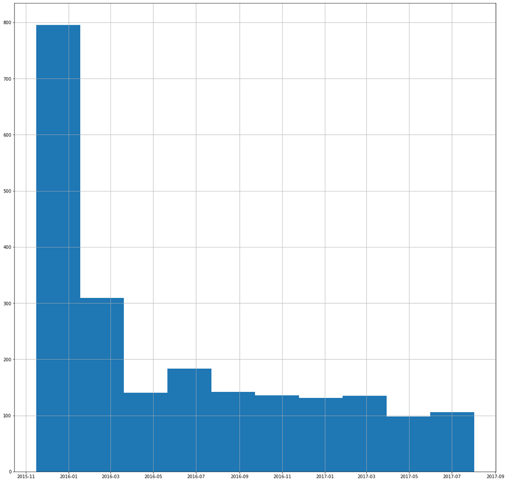

```python
tweets_enhanced_copy['timestamp'].hist(figsize = (20,20));
```

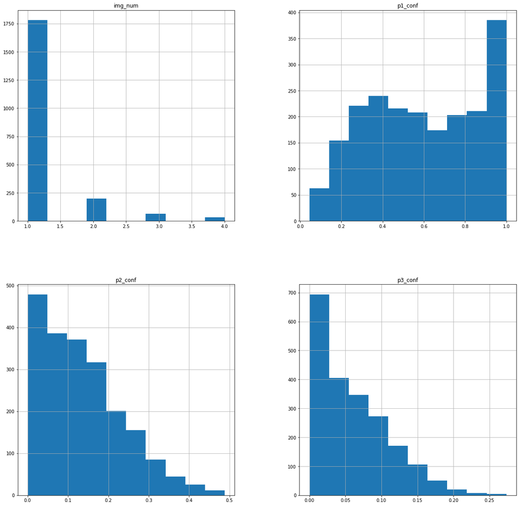

```python
image_pred_copy.hist(figsize = (20,20));
```

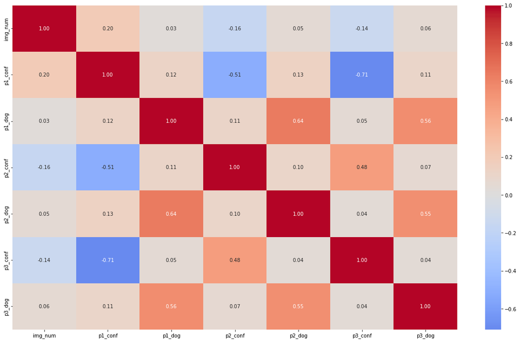

```python
#Plot a heatmap to show the correlation between the numeric variables, and use a diverging palette.
fig, ax = plt.subplots(figsize=(20,12))    # Sample figsize in inches
sns.heatmap(image_pred_copy.corr(), annot = True, fmt = '.2f', cmap = 'coolwarm', center = 0);
```

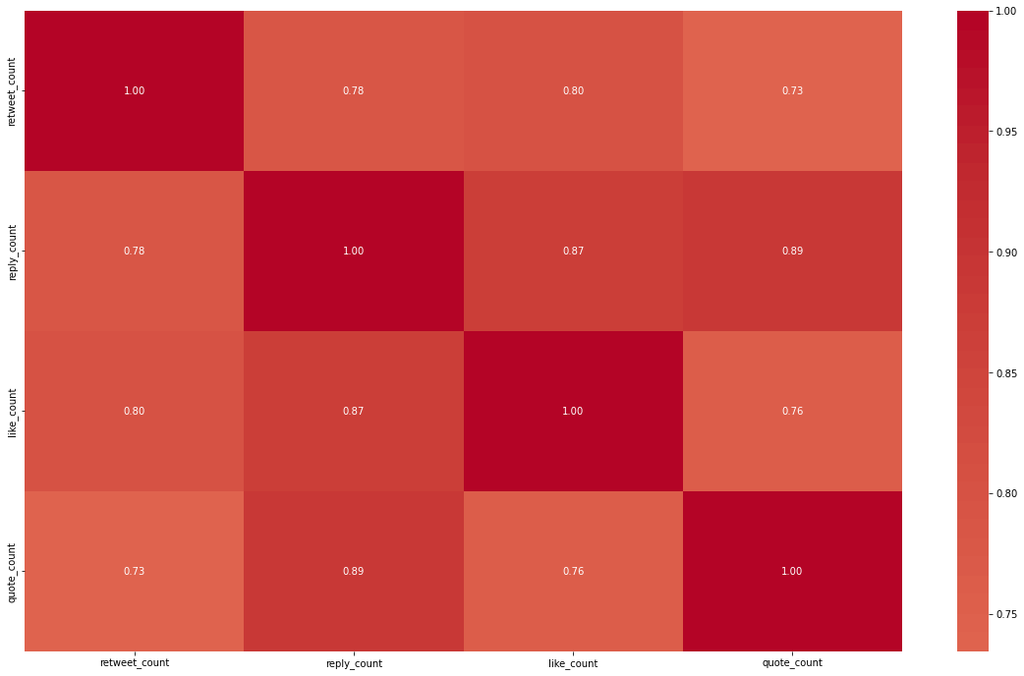

```python
#Plot a heatmap to show the correlation between the numeric variables, and use a diverging palette.
fig, ax = plt.subplots(figsize=(20,12))    # Sample figsize in inches
sns.heatmap(public_metrics_copy.corr(), annot = True, fmt = '.2f', cmap = 'coolwarm', center = 0);
```